# Social Mistreatment and Alcohol Use Problem Trajectories: The Moderating Effects of Brain Network Activations during the Stop Signal Task

# Intro

## Background

The risk for alcohol use disorder (AUD) is related to increased adverse life experiences such as social mistreatment. On the other hand, cognitive control is fundamental to facilitate self-control and psychological resilience, and has been proposed as a protector for AUD. However, the neural mechanism underlying the longitudinal association between these constructs remains unclear. This study examined the relationship between social mistreatment and the trajectories of alcohol use problem, while determining the moderating role of motor inhibition and error processing, which are the two important elements of cognitive control, using questionnaires, Stop Signal Task, and fMRI. In our preliminary analyses where we examined the relationship between AUDIT and social experiences and the moderation of inhibition (without modeling the trajectories). It seems that they might not relate to each other when we look at the data by separate waves of data collection. However, there are significant effects of social experiences and moderation of inhibition when we used ΔAUDIT as the outcome variable. Therefore, it is worth of trying to run HLM to model the slope of AUDIT.

## RQ

- Does social mistreatment predict the trajectories of alcohol problem in young adults?
- Does inhibitory control and error processing moderate the relationship between social mistreatment and the trajectories of alcohol problem in young adults?

## Hypothesis

- Social mistreatment is related to a greater increase of AUDIT score over time (i.e., steeper slope).
- Faster stop signal reaction time (SSRT) and greater post-error slowing (PES) are related mitigate the impact of social mistreatment on the AUDIT slope.
- Increased brain network activations of inhibition and error processing mitigate the impact of social mistreatment on the AUDIT slope.

## Methods

This is a longitudinal study where participants completed questionnaires and a Stop Signal Task during fMRI scanning at baseline (T0), and completed three yearly follow-up surveys (T1-T3). At baseline, the participants are all freshmen students in South Carolina; baseline n = 144, 1st follow-up n = 114, 2nd follow-up n = 83, 3rd follow-up n = 78. Exclusion criteria: 1) incomplete Stop Signal Task or fMRI data, 2) incomplete questionnaire data at baseline. All participants are right-handed. The fMRI data has been preprocessed and group-level comparisons were conducted: successful stop vs. go (SS-GO) and SS vs. failed stop (SS-FS) was completed (based on p = .001, cluster size = 31).

The current study oprationalized inhibition as SSRT and brain network activations during the Stop Signal Task based on the atlas of Power et al. (2011), which has 13 networks including 1. Sensory/somatomotor Hand, 2. Sensory/somatomotor Mouth, 3. Cingulo-opercular Task Control, 4. Auditory, 5. Default mode, 6. Memory retrieval?, 7. Visual, 8. Fronto-parietal Task Control, 9. Salience, 10. Subcortical, 11. Ventral attention, 12. Dorsal attention, and 13. Cerebellar. The activations in these networks were calculated as the betas of “successful stop - go” contrast averaged in each network.

We used the hierachical linear modeling approach to build linear growth models. Item-wise missing data within each questionnaire was interpolated with mean values if the response rate of that questionnaire is >= 50%; otherwise, the composite score was written as missing value (i.e., 9999).

### What we have tried in the previous analyses

We identified ROIs in the ss_stop-go contrast via 1) narrowing the significant level to p-value to 0.0000001 (cluster size still set as 31), 2) searching for the clusters where their peaks are located in inhibition areas based on the literature (i.e., IFG and insula), 3) looking at the coordinates of peak signals in those clusters, and 4) creating masks with a 10-mm radius sphere around these peaks. Four ROIs were identified (see the bolded ROIs below), which cover rIFG, lIFG, right insula, and left insula. Additionally, we also ran a correlation between SSRT and ss_stop-go contrast, and clusters of right (+19.5, +39.5, +51.5) and left SFG (-16.5, +55.5, +35.5) were identified (p = .001, cluster size = 31).

**Peak coordinates (order: LPI)**  
**p = .0000001, cluster = 31**  
**+55.5 +17.5 +31.5: rIFG, rMiddleFG, right precentralG** (this site survives even after clustering size 500)  
**-54.5 +13.5 +33.5: lIFG, lMiddleFG, left precentralG** (this site survives even after clustering size 500)  
**+49.5 +19.5 -8.5: rIFG, rInsula, rTemporal pole**  
**-48.5 +19.5 -8.5: lIFG, lTemporal pole** (this was also included in our analysis to represent left insula, although the coordinate of the peak is not exactly on left insula)  
+29.5 +55.5 +29.5: rSFG, rMiddleFG  
-30.5 +1.5 +67.5: lSFG, left precentralG  
-0.5 -30.5 +27.5: lPCC, lPCC, lMiddle CC, lMiddle CC  
+63.5 +7.5 +27.5: rIFG, right precentralG  
**p = .0000001, cluster = 500**  
+55.5 +17.5 +31.5: rIFG, rMiddleFG, right precentralG  
-54.5 +13.5 +33.5: lIFG, rMiddleFG, right precentralG

We also tried the network activations using the atlas from Yeo et al. (2011), which has 7-network and 17-network versions of segmentation. We ended up with Power’s 13-network atlas since it gives similar results as Yeo’s and has a medium number of networks compared to Yeo’s 7 and 17 networks.

# Data preparation and quick check

```r
# df <- read_excel('lia1.xlsx', col_names = TRUE, sheet = 'sstTemp')
df <- read_excel('lia1.xlsx', col_names = TRUE, sheet = 'sstTemp')
df <- df[,!names(df) %in% c("mriID_T1", "mriID_T2", "mriID_T3")]
df <- df %>%
  rename(AUDIT_T0 = auditTotal_T0, AUDIT_T1 = auditTotal_T1, AUDIT_T2 = auditTotal_T2, AUDIT_T3 = auditTotal_T3, SocialMis_T0 = ICSRLE_generalSocialMistreatment_T0, SocialMis_T1 = ICSRLE_generalSocialMistreatment_T1, SocialMis_T2 = ICSRLE_generalSocialMistreatment_T2, SocialMis_T3 = ICSRLE_generalSocialMistreatment_T3, NegLife_T0 = ICSRLE_total_T0, NegLife_T1 = ICSRLE_total_T1, NegLife_T2 = ICSRLE_total_T2, NegLife_T3 = ICSRLE_total_T3, NegLife_other_T0 = ICSRLE_other_T0, NegLife_other_T1 = ICSRLE_other_T1, NegLife_other_T2 = ICSRLE_other_T2, NegLife_other_T3 = ICSRLE_other_T3, AdChild = ACE_totalCorrected, CDRISC_Resilience = connorDavidsonResilienceScaleTotal, SUPPS_Impulsive = SUPPS_impulsiveBehaviorTotalCorrected, BIS_Impulsive = barrattImpulsivenessTotalCorrected, stateAnxiety = stateAnxietyInventoryCorrected, traitAnxiety = traitAnxietyInventoryCorrect, BDI_depression = bdiCorrected,
         GoAcc = goAcc, GoRT = goRT, StopAcc = stopAcc, SSD = ssd, SSRT = ssrt, go_subcortical = go_network_13_10,

         ss_somatomotorHand = ss_net_13_1, ss_somatomotorMouth = ss_net_13_2, ss_cinguloOpercularTaskControl = ss_net_13_3, ss_auditory = ss_net_13_4, ss_default = ss_net_13_5, ss_memoryRetrieval = ss_net_13_6, ss_visual = ss_net_13_7, ss_frontoParietalTaskControl =  ss_net_13_8, ss_salience =  ss_net_13_9, ss_subcortical =   ss_net_13_10, ss_ventralAttention = ss_net_13_11, ss_dorsalAttention =  ss_net_13_12, ss_cerebellar = ss_net_13_13,

         fs_somatomotorHand = fs_net_13_1, fs_somatomotorMouth = fs_net_13_2, fs_cinguloOpercularTaskControl = fs_net_13_3, fs_auditory = fs_net_13_4, fs_default = fs_net_13_5, fs_memoryRetrieval = fs_net_13_6, fs_visual = fs_net_13_7,fs_frontoParietalTaskControl =   fs_net_13_8,    fs_salience = fs_net_13_9, fs_subcortical = fs_net_13_10, fs_ventralAttention = fs_net_13_11, fs_dorsalAttention = fs_net_13_12, fs_cerebellar = fs_net_13_13,

         ssgo_somatomotorHand = ss_go_net_13_1, ssgo_somatomotorMouth = ss_go_net_13_2, ssgo_cinguloOpercularTaskControl = ss_go_net_13_3, ssgo_auditory = ss_go_net_13_4, ssgo_default = ss_go_net_13_5, ssgo_memoryRetrieval = ss_go_net_13_6, ssgo_visual = ss_go_net_13_7, ssgo_frontoParietalTaskControl = ss_go_net_13_8, ssgo_salience = ss_go_net_13_9, ssgo_subcortical = ss_go_net_13_10, ssgo_ventralAttention = ss_go_net_13_11, ssgo_dorsalAttention = ss_go_net_13_12, ssgo_cerebellar = ss_go_net_13_13,

         ssfs_somatomotorHand = ssfs_net_13_1, ssfs_somatomotorMouth = ssfs_net_13_2, ssfs_cinguloOpercularTaskControl = ssfs_net_13_3, ssfs_auditory = ssfs_net_13_4, ssfs_default = ssfs_net_13_5, ssfs_memoryRetrieval = ssfs_net_13_6, ssfs_visual = ssfs_net_13_7, ssfs_frontoParietalTaskControl = ssfs_net_13_8, ssfs_salience = ssfs_net_13_9, ssfs_subcortical = ssfs_net_13_10, ssfs_ventralAttention = ssfs_net_13_11, ssfs_dorsalAttention = ssfs_net_13_12, ssfs_cerebellar = ssfs_net_13_13,

         fsgo_somatomotorHand = fsgo_net_13_1, fsgo_somatomotorMouth = fsgo_net_13_2, fsgo_cinguloOpercularTaskControl = fsgo_net_13_3, fsgo_auditory = fsgo_net_13_4, fsgo_default = fsgo_net_13_5, fsgo_memoryRetrieval = fsgo_net_13_6, fsgo_visual = fsgo_net_13_7, fsgo_frontoParietalTaskControl = fsgo_net_13_8, fsgo_salience = fsgo_net_13_9, fsgo_subcortical = fsgo_net_13_10, fsgo_ventralAttention = fsgo_net_13_11, fsgo_dorsalAttention = fsgo_net_13_12, fsgo_cerebellar = fsgo_net_13_13,

         pfs_go_somatomotorHand = pfs_go_net_13_1, pfs_go_somatomotorMouth = pfs_go_net_13_2, pfs_go_cinguloOpercularTaskControl = pfs_go_net_13_3, pfs_go_auditory = pfs_go_net_13_4, pfs_go_default = pfs_go_net_13_5, pfs_go_memoryRetrieval = pfs_go_net_13_6, pfs_go_visual = pfs_go_net_13_7, pfs_go_frontoParietalTaskControl = pfs_go_net_13_8, pfs_go_salience = pfs_go_net_13_9, pfs_go_subcortical = pfs_go_net_13_10, pfs_go_ventralAttention = pfs_go_net_13_11, pfs_go_dorsalAttention = pfs_go_net_13_12, pfs_go_cerebellar = pfs_go_net_13_13,

         pss_go_somatomotorHand = pss_go_net_13_1, pss_go_somatomotorMouth = pss_go_net_13_2, pss_go_cinguloOpercularTaskControl = pss_go_net_13_3, pss_go_auditory = pss_go_net_13_4, pss_go_default = pss_go_net_13_5, pss_go_memoryRetrieval = pss_go_net_13_6, pss_go_visual = pss_go_net_13_7, pss_go_frontoParietalTaskControl = pss_go_net_13_8, pss_go_salience = pss_go_net_13_9, pss_go_subcortical = pss_go_net_13_10, pss_go_ventralAttention = pss_go_net_13_11, pss_go_dorsalAttention = pss_go_net_13_12, pss_go_cerebellar = pss_go_net_13_13)

# Since we only have SS-FS contrast in LIA1, here we copy and reverse the sign of SS-FS contrast betas to represent error processing (i.e., get FS-SS by * -1)
df <- df %>%
  mutate(across(
    c('ssfs_somatomotorHand', 'ssfs_somatomotorMouth', 'ssfs_cinguloOpercularTaskControl', 'ssfs_auditory', 'ssfs_default', 'ssfs_memoryRetrieval', 'ssfs_visual', 'ssfs_frontoParietalTaskControl', 'ssfs_salience', 'ssfs_subcortical', 'ssfs_ventralAttention','ssfs_dorsalAttention', 'ssfs_cerebellar'),
    ~ .x * -1, .names = "fsss_{sub('ssfs_', '', .col)}"))

# df <- df %>%
#   mutate(SocialMisdev_T0 = 0, SocialMisBaseline = SocialMis_T0,
#     SocialMisdev_T1 = SocialMis_T1 - SocialMis_T0,
#     SocialMisdev_T2 = SocialMis_T2 - SocialMis_T0,
#     SocialMisdev_T3 = SocialMis_T3 - SocialMis_T0)
df[df == 9999] <- NA # Replace 9999 with NA
# R
vars <- c("AUDIT_T0","AUDIT_T1","AUDIT_T2","AUDIT_T3", "SocialMis_T0","SocialMis_T1","SocialMis_T2","SocialMis_T3")
counts <- colSums(!is.na(df[vars]))
print(counts)
```

```
##     AUDIT_T0     AUDIT_T1     AUDIT_T2     AUDIT_T3 SocialMis_T0 SocialMis_T1 SocialMis_T2 SocialMis_T3
##          144          114           83           78          144          109           77           68
```

## Examine post-error performance before removing outliers, and examine if stop accuracy differs from 50%

```r
# Descriptive statistics
# pgc: post-go correct; pse: post-stop error; psc: post-stop correct; pea: post-error accuracy; pes: post-error slowing
vars <- c("pgc_trials", "pse_trials", "psc_trials", "post_stop_cor_acc", "post_stop_err_acc", "pea_pse_psc", "post_stop_cor_rt", "post_stop_err_rt", "pes_pse_psc")
for (v in vars) {
  cat("\nDescriptive stats for", v, ":\n")
  x <- df[[v]]
  cat(sprintf("Mean = %.3f, SD = %.3f, range: %.3f - %.3f (n = %d)\n",
            mean(x, na.rm = TRUE), sd(x, na.rm = TRUE), min(x, na.rm = TRUE), max(x, na.rm = TRUE), sum(!is.na(x))))}
```

```
##
## Descriptive stats for pgc_trials :
## Mean = 118.528, SD = 7.398, range: 65.000 - 122.000 (n = 144)
##
## Descriptive stats for pse_trials :
## Mean = 25.972, SD = 3.464, range: 14.000 - 33.000 (n = 144)
##
## Descriptive stats for psc_trials :
## Mean = 18.028, SD = 3.464, range: 11.000 - 30.000 (n = 144)
##
## Descriptive stats for post_stop_cor_acc :
## Mean = 97.326, SD = 7.828, range: 40.278 - 100.000 (n = 144)
##
## Descriptive stats for post_stop_err_acc :
## Mean = 97.356, SD = 4.739, range: 75.000 - 100.000 (n = 144)
##
## Descriptive stats for pea_pse_psc :
## Mean = -0.173, SD = 5.379, range: -16.667 - 31.667 (n = 144)
##
## Descriptive stats for post_stop_cor_rt :
## Mean = 710.587, SD = 170.250, range: 398.231 - 1270.158 (n = 144)
##
## Descriptive stats for post_stop_err_rt :
## Mean = 747.072, SD = 187.063, range: 408.078 - 1415.741 (n = 144)
##
## Descriptive stats for pes_pse_psc :
## Mean = 36.501, SD = 69.873, range: -129.258 - 187.478 (n = 144)
```

```r
# Paired t-test with effect size and 95%CI
paired_ttest <- function(x, y, xname, yname) {
  res <- t.test(x, y, paired = TRUE)
  d <- cohen.d(x, y, paired = TRUE, na.rm = TRUE)
  cat("\nPaired t-test:", xname, "vs.", yname, "\n")
  cat(sprintf("t = %.3f (p = %.3f, Cohen's d = %.3f, 95%% CI = %.3f to %.3f)\n",
            res$statistic, res$p.value, d$estimate, res$conf.int[1], res$conf.int[2]))}

# Run paired t-tests using dfUnscaled
paired_ttest(df$post_stop_err_acc, df$post_go_cor_acc, "post_stop_err_acc", "post_go_cor_acc")
```

```
##
## Paired t-test: post_stop_err_acc vs. post_go_cor_acc
## t = -1.357 (p = 0.177, Cohen's d = -0.103, 95% CI = -1.100 to 0.204)
```

```r
paired_ttest(df$post_stop_err_acc, df$post_stop_cor_acc, "post_stop_err_acc", "post_stop_cor_acc")
```

```
##
## Paired t-test: post_stop_err_acc vs. post_stop_cor_acc
## t = 0.057 (p = 0.955, Cohen's d = 0.004, 95% CI = -1.014 to 1.074)
```

```r
paired_ttest(df$post_stop_err_rt, df$post_go_cor_rt, "post_stop_err_rt", "post_go_cor_rt")
```

```
##
## Paired t-test: post_stop_err_rt vs. post_go_cor_rt
## t = -4.831 (p = 0.000, Cohen's d = -0.127, 95% CI = -35.077 to -14.706)
```

```r
paired_ttest(df$post_stop_err_rt, df$post_stop_cor_rt, "post_stop_err_rt", "post_stop_cor_rt")
```

```
##
## Paired t-test: post_stop_err_rt vs. post_stop_cor_rt
## t = 6.319 (p = 0.000, Cohen's d = 0.198, 95% CI = 25.071 to 47.898)
```

```r
# normality
print(shapiro_res <- tryCatch(shapiro.test(df$StopAcc), error = function(e) e))
```

```
##
##  Shapiro-Wilk normality test
##
## data:  df$StopAcc
## W = 0.77002, p-value = 9.437e-14
```

```r
# one-sample t-test vs 50 with 95% CI
t_res <- t.test(df$StopAcc, mu = 50, alternative = "two.sided", conf.level = 0.95)
print(t_res)
```

```
##
##  One Sample t-test
##
## data:  df$StopAcc
## t = -14.67, df = 143, p-value < 2.2e-16
## alternative hypothesis: true mean is not equal to 50
## 95 percent confidence interval:
##  39.63622 42.09752
## sample estimates:
## mean of x
##  40.86687
```

```r
cat("95% CI for mean:", round(t_res$conf.int[1],2), "-", round(t_res$conf.int[2],2), "\n\n")
```

```
## 95% CI for mean: 39.64 - 42.1
```

```r
cat("Cohen's d (one-sample) =", round(d <- (mean(df$StopAcc) - 50) / sd(df$StopAcc), 3), "\n")
```

```
## Cohen's d (one-sample) = -1.222
```

```r
print(summary(df$StopAcc))
```

```
##    Min. 1st Qu.  Median    Mean 3rd Qu.    Max.
##   32.05   36.08   38.68   40.87   42.31   69.12
```

### Distribution of PES and PEA before removing outliers

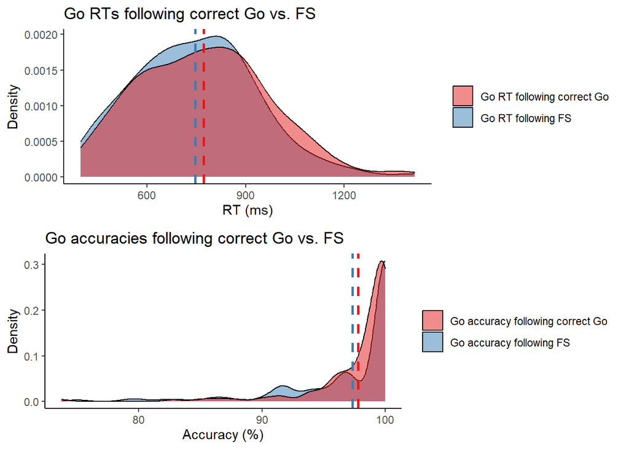

```r
mean_err_rt <- mean(df$post_stop_err_rt, na.rm = TRUE)
mean_go_cor_rt <- mean(df$post_go_cor_rt, na.rm = TRUE)
mean_stop_cor_rt <- mean(df$post_stop_cor_rt, na.rm = TRUE)
mean_err_acc <- mean(df$post_stop_err_acc, na.rm = TRUE)
mean_go_cor_acc <- mean(df$post_go_cor_acc, na.rm = TRUE)
mean_stop_cor_acc <- mean(df$post_stop_cor_acc, na.rm = TRUE)

# Post-stop-error vs post-go-correct RTs
p1 <- ggplot(df, aes(x = post_stop_err_rt)) +
  geom_density(aes(fill = "post_stop_err_rt"), alpha = 0.5) +
  geom_density(aes(x = post_go_cor_rt, fill = "post_go_cor_rt"), alpha = 0.5) +
  geom_vline(xintercept = mean_err_rt, color = "#377eb8", linetype = "dashed", linewidth = 1) +
  geom_vline(xintercept = mean_go_cor_rt, color = "#e41a1c", linetype = "dashed", linewidth = 1) +
  labs(title = "Go RTs following correct Go vs. FS", x = "RT (ms)", y = "Density", fill = "Variable") +
  scale_fill_manual(name = NULL, values = c("post_stop_err_rt" = "#377eb8", "post_go_cor_rt" = "#e41a1c"),
                    labels = c("post_stop_err_rt" = "Go RT following FS", "post_go_cor_rt" = "Go RT following correct Go")) +
  theme_classic()

# Post-stop-error vs post-stop-correct RTs
p2 <- ggplot(df, aes(x = post_stop_err_rt)) +
  geom_density(aes(fill = "post_stop_err_rt"), alpha = 0.5) +
  geom_density(aes(x = post_stop_cor_rt, fill = "post_stop_cor_rt"), alpha = 0.5) +
  geom_vline(xintercept = mean_err_rt, color = "#377eb8", linetype = "dashed", linewidth = 1) +
  geom_vline(xintercept = mean_stop_cor_rt, color = "#e41a1c", linetype = "dashed", linewidth = 1) +
  labs(title = "Go RTs following SS vs. FS", x = "RT (ms)", y = "Density", fill = "Variable") +
  scale_fill_manual(name = NULL, values = c("post_stop_err_rt" = "#377eb8", "post_stop_cor_rt" = "#e41a1c"),
                    labels = c("post_stop_err_rt" = "Go RT following FS", "post_stop_cor_rt" = "Go RT following SS")) +
  theme_classic()

# Post-stop-error vs post-go-correct Accuracies
p3 <- ggplot(df, aes(x = post_stop_err_acc)) +
  geom_density(aes(fill = "post_stop_err_acc"), alpha = 0.5) +
  geom_density(aes(x = post_go_cor_acc, fill = "post_go_cor_acc"), alpha = 0.5) +
  geom_vline(xintercept = mean_err_acc, color = "#377eb8", linetype = "dashed", linewidth = 1) +
  geom_vline(xintercept = mean_go_cor_acc, color = "#e41a1c", linetype = "dashed", linewidth = 1) +
  labs(title = "Go accuracies following correct Go vs. FS", x = "Accuracy (%)", y = "Density", fill = "Variable") +
  scale_fill_manual(name = NULL, values = c("post_stop_err_acc" = "#377eb8", "post_go_cor_acc" = "#e41a1c"),
                    labels = c("post_stop_err_acc" = "Go accuracy following FS", "post_go_cor_acc" = "Go accuracy following correct Go")) +
  theme_classic()

# Post-stop-error vs post-stop-correct Accuracies
p4 <- ggplot(df, aes(x = post_stop_err_acc)) +
  geom_density(aes(fill = "post_stop_err_acc"), alpha = 0.5) +
  geom_density(aes(x = post_stop_cor_acc, fill = "post_stop_cor_acc"), alpha = 0.5) +
  geom_vline(xintercept = mean_err_acc, color = "#377eb8", linetype = "dashed", linewidth = 1.2) +
  geom_vline(xintercept = mean_stop_cor_acc, color = "#e41a1c", linetype = "dashed", linewidth = 1) +
  labs(title = "Go accuracies following SS vs. FS", x = "Accuracy (%)", y = "Density", fill = "Variable") +
  scale_fill_manual(name = NULL, values = c("post_stop_err_acc" = "#377eb8", "post_stop_cor_acc" = "#e41a1c"),
                    labels = c("post_stop_err_acc" = "Go accuracy following FS", "post_stop_cor_acc" = "Go accuracy following SS")) +
  theme_classic()

# Based on the t-tests and distribution plots, we can see significant post-error speeding (i.e., negative PES) when comparing post-stop-error RT to post-go-correct RT, and significant post-error-slowing (i.e., positive PES) when comparing post-stop-error RT to post-stop correct RT.
ggarrange(p1, p3, ncol = 1, nrow = 2, common.legend = FALSE, legend = "right")
```

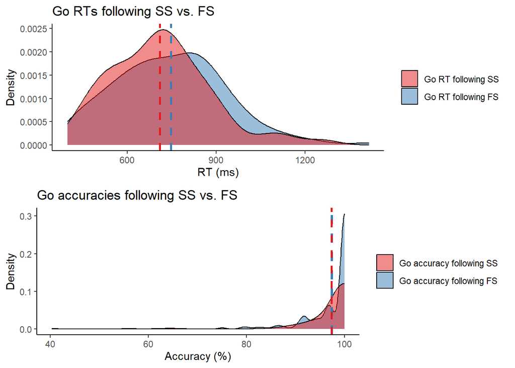

```r
ggarrange(p2, p4, ncol = 1, nrow = 2, common.legend = FALSE, legend = "right")
```

```r
tiff('Post_stop_err_post_go_cor_distribution_w.outlier.tiff', width = 2000, height = 2000, res = 300)
ggarrange(p1, p3, ncol = 1, nrow = 2, common.legend = FALSE, legend = "right")
dev.off()
```

```r
tiff('Post_stop_err_post_stop_cor_distribution_w.outlier.tiff', width = 2000, height = 2000, res = 300)
ggarrange(p2, p4, ncol = 1, nrow = 2, common.legend = FALSE, legend = "right")
dev.off()
```

## Correlations before removing outliers: 1) SSRT and SS-Go brain activations, 2) pea_pse_psc, pes_pse_psc, and FS-SS brain activations, and 3) pea_pse_psc, pes_pse_psc, and FS brain activations

```r
behav_corr <- corr_coef(df[, c("GoAcc", "GoRT", "StopAcc", "SSD", "SSRT", "pes_pse_psc", "pea_pse_psc")])
behav_corr
```

```
## ---------------------------------------------------------------------------
## Pearson's correlation coefficient
## ---------------------------------------------------------------------------
##              GoAcc    GoRT StopAcc     SSD    SSRT pes_pse_psc pea_pse_psc
## GoAcc        1.000 -0.1657 -0.4287 -0.2029 -0.1319      0.1792     -0.4980
## GoRT        -0.166  1.0000  0.7577  0.9322  0.0832      0.2854     -0.1925
## StopAcc     -0.429  0.7577  1.0000  0.6694 -0.0223      0.0922     -0.0500
## SSD         -0.203  0.9322  0.6694  1.0000 -0.2028      0.2956     -0.0942
## SSRT        -0.132  0.0832 -0.0223 -0.2028  1.0000     -0.1070     -0.0450
## pes_pse_psc  0.179  0.2854  0.0922  0.2956 -0.1070      1.0000     -0.1684
## pea_pse_psc -0.498 -0.1925 -0.0500 -0.0942 -0.0450     -0.1684      1.0000
## ---------------------------------------------------------------------------
## p-values for the correlation coefficients
## ---------------------------------------------------------------------------
##                GoAcc     GoRT  StopAcc      SSD   SSRT pes_pse_psc pea_pse_psc
## GoAcc       0.00e+00 4.71e-02 8.31e-08 1.47e-02 0.1149    0.031624    2.13e-10
## GoRT        4.71e-02 0.00e+00 4.22e-28 1.52e-64 0.3213    0.000526    2.08e-02
## StopAcc     8.31e-08 4.22e-28 0.00e+00 4.62e-20 0.7903    0.271823    5.51e-01
## SSD         1.47e-02 1.52e-64 4.62e-20 0.00e+00 0.0148    0.000322    2.61e-01
## SSRT        1.15e-01 3.21e-01 7.90e-01 1.48e-02 0.0000    0.201653    5.93e-01
## pes_pse_psc 3.16e-02 5.26e-04 2.72e-01 3.22e-04 0.2017    0.000000    4.36e-02
## pea_pse_psc 2.13e-10 2.08e-02 5.51e-01 2.61e-01 0.5925    0.043616    0.00e+00
```

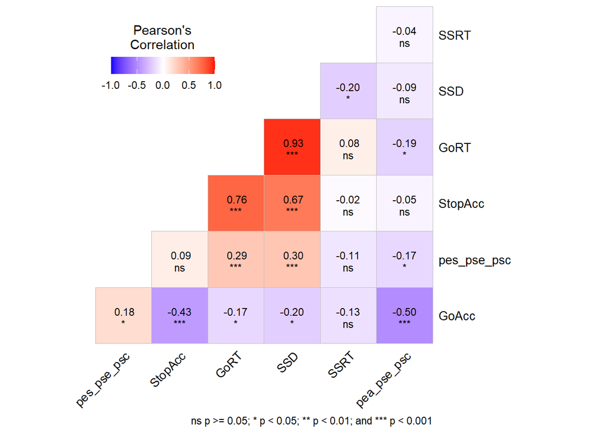

```r
plot(behav_corr, col.low = "blue", col.mid = "white", col.high ="red", order = "original")
```

```r
# SSRT didn't correlate with PEA_pse_psc or PES_pse_psc.
# pes_pse_psc had significantly negative correlation with pea_pse_psc, indicating that greater post-error slowing is related to lower post-error accuracy.

# Correlation between SSRT and SS-Go brain activations
df <- df %>% rename("Somatomotor-Hand" = ssgo_somatomotorHand, "Somatomotor-Mouth" = ssgo_somatomotorMouth, "Cingulo-Opercular" = ssgo_cinguloOpercularTaskControl, Auditory = ssgo_auditory, "Default Mode" = ssgo_default, "Memory Retrieval" = ssgo_memoryRetrieval,  Visual = ssgo_visual,  "Fronto-Parietal" = ssgo_frontoParietalTaskControl, Salience = ssgo_salience, Subcortical = ssgo_subcortical, "Ventral Attention" = ssgo_ventralAttention, "Dorsal Attention" = ssgo_dorsalAttention, Cerebellar = ssgo_cerebellar)
ssrt_ssgo_corr <- corr_coef(df[, c("Cerebellar", "Somatomotor-Hand", "Somatomotor-Mouth", "Cingulo-Opercular", "Auditory", "Default Mode", "Memory Retrieval", "Dorsal Attention", "Fronto-Parietal", "Salience", "Ventral Attention", "Subcortical", "Visual", "SSRT")])
ssrt_ssgo_corr
```

```
## ---------------------------------------------------------------------------
## Pearson's correlation coefficient
## ---------------------------------------------------------------------------
##                   Cerebellar Somatomotor-Hand Somatomotor-Mouth Cingulo-Opercular Auditory Default Mode Memory Retrieval Dorsal Attention Fronto-Parietal Salience Ventral Attention Subcortical Visual    SSRT
## Cerebellar            1.0000            0.496             0.389            0.6176    0.464       0.1323            0.270            0.451          0.4289    0.475             0.322       0.635  0.382  0.0626
## Somatomotor-Hand      0.4957            1.000             0.725            0.6358    0.859       0.3697            0.442            0.655          0.4061    0.379             0.495       0.401  0.559 -0.1455
## Somatomotor-Mouth     0.3891            0.725             1.000            0.4753    0.740       0.4054            0.379            0.481          0.4181    0.360             0.495       0.303  0.506 -0.1375
## Cingulo-Opercular     0.6176            0.636             0.475            1.0000    0.731       0.0833            0.256            0.599          0.4281    0.713             0.514       0.716  0.426 -0.0051
## Auditory              0.4642            0.859             0.740            0.7309    1.000       0.3967            0.428            0.603          0.4181    0.452             0.587       0.483  0.568 -0.1674
## Default Mode          0.1323            0.370             0.405            0.0833    0.397       1.0000            0.661            0.311          0.3721    0.153             0.649       0.193  0.492 -0.3676
## Memory Retrieval      0.2703            0.442             0.379            0.2562    0.428       0.6609            1.000            0.554          0.4296    0.335             0.575       0.265  0.597 -0.3017
## Dorsal Attention      0.4514            0.655             0.481            0.5987    0.603       0.3113            0.554            1.000          0.6115    0.589             0.605       0.416  0.716 -0.1516
## Fronto-Parietal       0.4289            0.406             0.418            0.4281    0.418       0.3721            0.430            0.612          1.0000    0.727             0.642       0.400  0.416 -0.0174
## Salience              0.4750            0.379             0.360            0.7127    0.452       0.1529            0.335            0.589          0.7267    1.000             0.597       0.570  0.364  0.1082
## Ventral Attention     0.3217            0.495             0.495            0.5145    0.587       0.6493            0.575            0.605          0.6416    0.597             1.000       0.393  0.571 -0.1599
## Subcortical           0.6351            0.401             0.303            0.7157    0.483       0.1933            0.265            0.416          0.3997    0.570             0.393       1.000  0.316 -0.0820
## Visual                0.3824            0.559             0.506            0.4265    0.568       0.4917            0.597            0.716          0.4156    0.364             0.571       0.316  1.000 -0.2209
## SSRT                  0.0626           -0.145            -0.137           -0.0051   -0.167      -0.3676           -0.302           -0.152         -0.0174    0.108            -0.160      -0.082 -0.221  1.0000
## ---------------------------------------------------------------------------
## p-values for the correlation coefficients
## ---------------------------------------------------------------------------
##                   Cerebellar Somatomotor-Hand Somatomotor-Mouth Cingulo-Opercular Auditory Default Mode Memory Retrieval Dorsal Attention Fronto-Parietal Salience Ventral Attention Subcortical   Visual     SSRT
## Cerebellar          0.00e+00         2.67e-10          1.44e-06          1.65e-16 4.64e-09     1.14e-01         1.05e-03         1.36e-08        8.19e-08 1.80e-09          8.43e-05    1.25e-17 2.25e-06 4.56e-01
## Somatomotor-Hand    2.67e-10         0.00e+00          1.01e-24          1.12e-17 3.35e-43     5.10e-06         3.02e-08         5.58e-19        4.41e-07 2.85e-06          2.90e-10    6.35e-07 3.48e-13 8.19e-02
```

[output cut: 12 more lines]

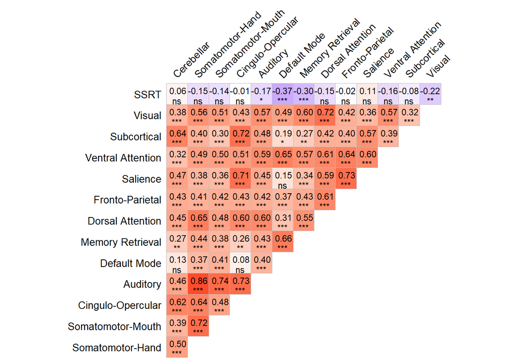

```r
# tiff('ssrt_ssgo_corr_plot.tiff', width = 2800, height = 2000, res = 300)
# plot(ssrt_ssgo_corr, col.low = "blue", col.mid = "white", col.high ="red", reorder = FALSE, caption = FALSE, type = "upper", legend.position = "upper right")
# dev.off()
plot(ssrt_ssgo_corr, col.low = "blue", col.mid = "white", col.high ="red", reorder = FALSE, caption = FALSE, type = "upper", legend.position = "upper right")
```

```r
df <- df %>% rename(ssgo_somatomotorHand = "Somatomotor-Hand", ssgo_somatomotorMouth = "Somatomotor-Mouth", ssgo_cinguloOpercularTaskControl = "Cingulo-Opercular", ssgo_auditory = Auditory,
  ssgo_default = "Default Mode",  ssgo_memoryRetrieval = "Memory Retrieval", ssgo_visual = Visual, ssgo_frontoParietalTaskControl = "Fronto-Parietal", ssgo_salience = Salience, ssgo_subcortical = Subcortical,
  ssgo_ventralAttention = "Ventral Attention", ssgo_dorsalAttention = "Dorsal Attention", ssgo_cerebellar = Cerebellar)
# SSRT had significantly negative correlations with networks 4 (auditory), 5 (default), 6 (memoryRetrieval), and 7 (visual), greater activations in these networks are related to better inhibition (i.e., lower SSRT).

# Correlation between pes_pse_psc and FS-Go brain activations
df <- df %>% rename(PES = pes_pse_psc, "Somatomotor-Hand" = fsgo_somatomotorHand, "Somatomotor-Mouth" = fsgo_somatomotorMouth, "Cingulo-Opercular" = fsgo_cinguloOpercularTaskControl, Auditory = fsgo_auditory, "Default Mode" = fsgo_default, "Memory Retrieval" = fsgo_memoryRetrieval,  Visual = fsgo_visual,  "Fronto-Parietal" = fsgo_frontoParietalTaskControl, Salience = fsgo_salience, Subcortical = fsgo_subcortical, "Ventral Attention" = fsgo_ventralAttention, "Dorsal Attention" = fsgo_dorsalAttention, Cerebellar = fsgo_cerebellar)
pes_fsgo_corr <- corr_coef(df[, c("PES", "Cerebellar", "Somatomotor-Hand", "Somatomotor-Mouth", "Cingulo-Opercular", "Auditory", "Default Mode", "Memory Retrieval", "Dorsal Attention", "Fronto-Parietal", "Salience", "Ventral Attention", "Subcortical", "Visual")])
pes_fsgo_corr
```

```
## ---------------------------------------------------------------------------
## Pearson's correlation coefficient
## ---------------------------------------------------------------------------
##                       PES Cerebellar Somatomotor-Hand Somatomotor-Mouth Cingulo-Opercular Auditory Default Mode Memory Retrieval Dorsal Attention Fronto-Parietal Salience Ventral Attention Subcortical  Visual
## PES                1.0000     -0.134          -0.0934           -0.0683           -0.1581   -0.156       0.0589          -0.0209          -0.1042          -0.132   -0.172            0.0955      -0.165 -0.0646
## Cerebellar        -0.1344      1.000           0.6816            0.5330            0.6802    0.676       0.2016           0.4389           0.6852           0.449    0.597            0.4766       0.600  0.6081
## Somatomotor-Hand  -0.0934      0.682           1.0000            0.6002            0.6728    0.745       0.1280           0.3493           0.7056           0.291    0.454            0.3362       0.483  0.5933
## Somatomotor-Mouth -0.0683      0.533           0.6002            1.0000            0.3650    0.671       0.2354           0.2518           0.4369           0.241    0.333            0.3883       0.298  0.4279
## Cingulo-Opercular -0.1581      0.680           0.6728            0.3650            1.0000    0.713      -0.0888           0.3434           0.6414           0.350    0.697            0.3938       0.681  0.4187
## Auditory          -0.1556      0.676           0.7452            0.6710            0.7130    1.000       0.1161           0.2821           0.5767           0.202    0.466            0.4169       0.543  0.5434
## Default Mode       0.0589      0.202           0.1280            0.2354           -0.0888    0.116       1.0000           0.4765           0.0301           0.309    0.144            0.4751       0.103  0.2453
## Memory Retrieval  -0.0209      0.439           0.3493            0.2518            0.3434    0.282       0.4765           1.0000           0.5160           0.502    0.479            0.3405       0.351  0.3819
## Dorsal Attention  -0.1042      0.685           0.7056            0.4369            0.6414    0.577       0.0301           0.5160           1.0000           0.511    0.585            0.4286       0.510  0.6495
## Fronto-Parietal   -0.1316      0.449           0.2912            0.2410            0.3502    0.202       0.3087           0.5022           0.5106           1.000    0.680            0.4357       0.385  0.2452
## Salience          -0.1720      0.597           0.4536            0.3326            0.6974    0.466       0.1442           0.4790           0.5846           0.680    1.000            0.4684       0.646  0.3986
## Ventral Attention  0.0955      0.477           0.3362            0.3883            0.3938    0.417       0.4751           0.3405           0.4286           0.436    0.468            1.0000       0.350  0.4258
## Subcortical       -0.1654      0.600           0.4828            0.2983            0.6811    0.543       0.1025           0.3507           0.5099           0.385    0.646            0.3497       1.000  0.3324
## Visual            -0.0646      0.608           0.5933            0.4279            0.4187    0.543       0.2453           0.3819           0.6495           0.245    0.399            0.4258       0.332  1.0000
## ---------------------------------------------------------------------------
## p-values for the correlation coefficients
## ---------------------------------------------------------------------------
##                      PES Cerebellar Somatomotor-Hand Somatomotor-Mouth Cingulo-Opercular Auditory Default Mode Memory Retrieval Dorsal Attention Fronto-Parietal Salience Ventral Attention Subcortical   Visual
## PES               0.0000   1.08e-01         2.65e-01          4.16e-01          5.83e-02 6.25e-02     4.83e-01         8.04e-01         2.14e-01        1.16e-01 3.93e-02          2.55e-01    4.75e-02 4.42e-01
## Cerebellar        0.1082   0.00e+00         5.36e-21          6.08e-12          6.89e-21 1.52e-20     1.54e-02         3.74e-08         2.76e-21        1.67e-08 2.92e-15          1.55e-09    1.98e-15 6.27e-16
```

[output cut: 12 more lines]

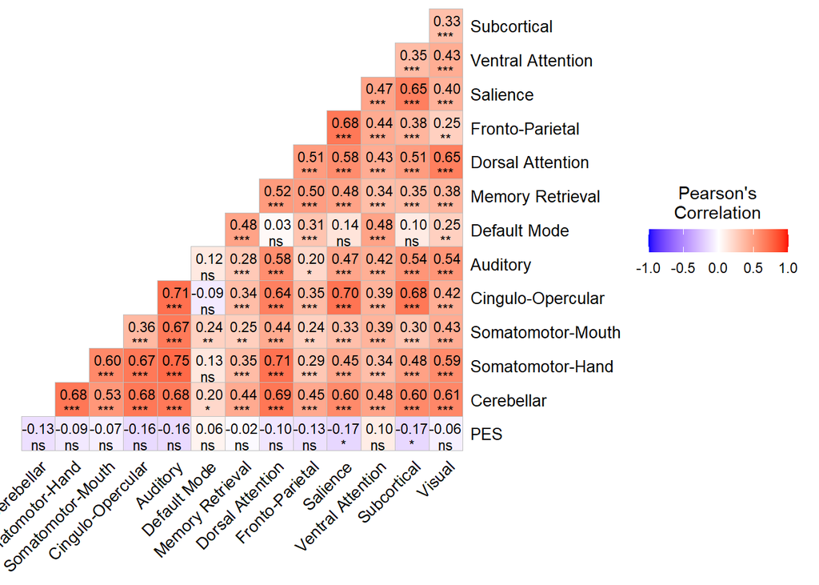

```r
# tiff('pes_fsgo_corr_plot.tiff', width = 2800, height = 2000, res = 300)
# plot(pes_fsgo_corr, col.low = "blue", col.mid = "white", col.high ="red", reorder = FALSE, caption = FALSE, legend.position = "right")
# dev.off()
plot(pes_fsgo_corr, col.low = "blue", col.mid = "white", col.high ="red", reorder = FALSE, caption = FALSE, legend.position = "right")
```

```r
df <- df %>% rename(pes_pse_psc = PES, fsgo_somatomotorHand = "Somatomotor-Hand", fsgo_somatomotorMouth = "Somatomotor-Mouth", fsgo_cinguloOpercularTaskControl = "Cingulo-Opercular", fsgo_auditory = Auditory, fsgo_default = "Default Mode",  fsgo_memoryRetrieval = "Memory Retrieval", fsgo_visual = Visual, fsgo_frontoParietalTaskControl = "Fronto-Parietal", fsgo_salience = Salience, fsgo_subcortical = Subcortical,  fsgo_ventralAttention = "Ventral Attention", fsgo_dorsalAttention = "Dorsal Attention", fsgo_cerebellar = Cerebellar)
# PEA_pse_psc didn't correlated with any networks, and it is not observed in LIA1. PES_pse_psc had significantly negative correlations with salience and subcortical networks.

# Combine the above plots into one figure for publication
p1 <- plot(ssrt_ssgo_corr, col.low = "blue", col.mid = "white", col.high = "red", reorder = FALSE, caption = FALSE, type = "upper", legend.position = "upper right")
p2 <- plot(pes_fsgo_corr, col.low = "blue", col.mid = "white", col.high = "red", reorder = FALSE, caption = FALSE, legend.position = "upper right")
combined_plot <- ggarrange(p1, p2, labels = c("(a) SSRT", "(b) PES"), label.x = 0.2)
tiff('behav_net_corr_plots.tiff', width = 4000, height = 2000, res = 300)
print(combined_plot)
dev.off()
```

```r
# Extra analyses that aren't included in the manuscript
pe_fsss_corr <- corr_coef(df[, c("pes_pse_psc", "pea_pse_psc", 'fsss_somatomotorHand', 'fsss_somatomotorMouth', 'fsss_cinguloOpercularTaskControl', 'fsss_auditory', 'fsss_default', 'fsss_memoryRetrieval', 'fsss_visual', 'fsss_frontoParietalTaskControl', 'fsss_salience', 'fsss_subcortical', 'fsss_ventralAttention', 'fsss_dorsalAttention', 'fsss_cerebellar')])
pe_fsss_corr
```

```
## ---------------------------------------------------------------------------
## Pearson's correlation coefficient
## ---------------------------------------------------------------------------
##                                  pes_pse_psc pea_pse_psc fsss_somatomotorHand fsss_somatomotorMouth fsss_cinguloOpercularTaskControl fsss_auditory fsss_default fsss_memoryRetrieval fsss_visual fsss_frontoParietalTaskControl fsss_salience fsss_subcortical fsss_ventralAttention fsss_dorsalAttention
## pes_pse_psc                          1.00000     -0.1684               0.0942                0.0434                           0.0112        0.0461      -0.0384              -0.0123      0.0594                        0.00907      -0.00352          -0.0918                 0.118                0.101
## pea_pse_psc                         -0.16841      1.0000              -0.3295               -0.1818                          -0.1488       -0.2226      -0.1340              -0.1420     -0.1955                       -0.15015      -0.10369           0.0523                -0.294               -0.230
## fsss_somatomotorHand                 0.09416     -0.3295               1.0000                0.6756                           0.5623        0.8065       0.3863               0.4158      0.6943                        0.31559       0.30072           0.2439                 0.596                0.701
## fsss_somatomotorMouth                0.04336     -0.1818               0.6756                1.0000                           0.3746        0.7337       0.4194               0.2659      0.5117                        0.21463       0.21152           0.2019                 0.538                0.427
## fsss_cinguloOpercularTaskControl     0.01121     -0.1488               0.5623                0.3746                           1.0000        0.7241       0.0942               0.4247      0.4323                        0.43443       0.71960           0.6952                 0.549                0.632
## fsss_auditory                        0.04611     -0.2226               0.8065                0.7337                           0.7241        1.0000       0.3639               0.4537      0.6236                        0.30744       0.42636           0.4184                 0.669                0.632
## fsss_default                        -0.03841     -0.1340               0.3863                0.4194                           0.0942        0.3639       1.0000               0.6141      0.4324                        0.39207       0.24691           0.1315                 0.634                0.276
## fsss_memoryRetrieval                -0.01232     -0.1420               0.4158                0.2659                           0.4247        0.4537       0.6141               1.0000      0.5322                        0.49873       0.48442           0.3399                 0.539                0.591
## fsss_visual                          0.05940     -0.1955               0.6943                0.5117                           0.4323        0.6236       0.4324               0.5322      1.0000                        0.28347       0.34476           0.2486                 0.579                0.733
## fsss_frontoParietalTaskControl       0.00907     -0.1501               0.3156                0.2146                           0.4344        0.3074       0.3921               0.4987      0.2835                        1.00000       0.76750           0.4689                 0.541                0.566
## fsss_salience                       -0.00352     -0.1037               0.3007                0.2115                           0.7196        0.4264       0.2469               0.4844      0.3448                        0.76750       1.00000           0.6763                 0.561                0.542
## fsss_subcortical                    -0.09176      0.0523               0.2439                0.2019                           0.6952        0.4184       0.1315               0.3399      0.2486                        0.46887       0.67634           1.0000                 0.403                0.410
## fsss_ventralAttention                0.11768     -0.2935               0.5962                0.5383                           0.5489        0.6685       0.6335               0.5386      0.5790                        0.54125       0.56070           0.4029                 1.000                0.606
## fsss_dorsalAttention                 0.10103     -0.2304               0.7011                0.4268                           0.6319        0.6320       0.2756               0.5905      0.7332                        0.56576       0.54154           0.4097                 0.606                1.000
## fsss_cerebellar                      0.01396      0.0577               0.4939                0.4087                           0.7020        0.5918       0.1418               0.4015      0.4782                        0.46004       0.60059           0.6855                 0.412                0.585
##                                  fsss_cerebellar
## pes_pse_psc                               0.0140
## pea_pse_psc                               0.0577
## fsss_somatomotorHand                      0.4939
## fsss_somatomotorMouth                     0.4087
## fsss_cinguloOpercularTaskControl          0.7020
## fsss_auditory                             0.5918
```

[output cut: 44 more lines]

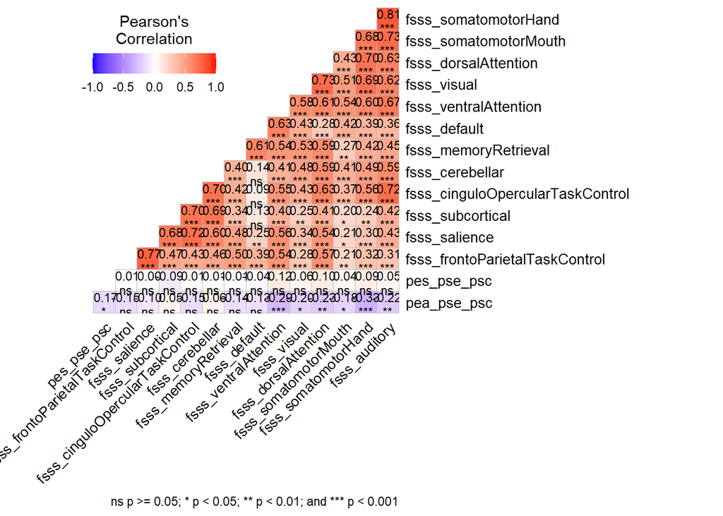

```r
plot(pe_fsss_corr, col.low = "blue", col.mid = "white", col.high ="red", order = "original")
```

```r
# PES_pse_psc didn't have significant correlations with any networks; but, PEA_pse_psc had significantly negative correlations with auditory, somatomotor-hand, somatomotor-mouth, dorsal attention, visual, and ventral attention networks, indicating that greater activations in these networks are related to lower improment in post-error accuracy. But, PEA didn't exist in LIA1.

# Neither pea_pse_psc nor pes_pse_psc had significant correlations with pfs_go networks.
pe_pfsgo_corr <- corr_coef(df[, c("pes_pse_psc", "pea_pse_psc", 'pfs_go_somatomotorHand', 'pfs_go_somatomotorMouth', 'pfs_go_cinguloOpercularTaskControl', 'pfs_go_auditory', 'pfs_go_default', 'pfs_go_memoryRetrieval', 'pfs_go_visual', 'pfs_go_frontoParietalTaskControl', 'pfs_go_salience', 'pfs_go_subcortical', 'pfs_go_ventralAttention', 'pfs_go_dorsalAttention', 'pfs_go_cerebellar')])
pe_pfsgo_corr
```

```
## ---------------------------------------------------------------------------
## Pearson's correlation coefficient
## ---------------------------------------------------------------------------
##                                    pes_pse_psc pea_pse_psc pfs_go_somatomotorHand pfs_go_somatomotorMouth pfs_go_cinguloOpercularTaskControl pfs_go_auditory pfs_go_default pfs_go_memoryRetrieval pfs_go_visual pfs_go_frontoParietalTaskControl pfs_go_salience pfs_go_subcortical
## pes_pse_psc                           1.000000    -0.16841                 -0.106                 -0.0354                             0.0462        0.000918       -0.04961                -0.1374      0.000722                          -0.0912         -0.0433             -0.102
## pea_pse_psc                          -0.168412     1.00000                 -0.013                  0.0963                             0.0267        0.008984        0.00559                 0.0136      0.046704                           0.0641          0.0666              0.064
## pfs_go_somatomotorHand               -0.105740    -0.01303                  1.000                  0.4779                             0.5580        0.687537        0.28263                 0.2822      0.279324                           0.2640          0.2315              0.574
## pfs_go_somatomotorMouth              -0.035446     0.09631                  0.478                  1.0000                             0.4526        0.653610        0.15121                 0.0897      0.162675                           0.2259          0.1395              0.423
## pfs_go_cinguloOpercularTaskControl    0.046183     0.02674                  0.558                  0.4526                             1.0000        0.677232       -0.15591                 0.1696      0.415739                           0.3656          0.6691              0.661
## pfs_go_auditory                       0.000918     0.00898                  0.688                  0.6536                             0.6772        1.000000        0.05898                 0.0850      0.246766                           0.1223          0.2009              0.596
## pfs_go_default                       -0.049614     0.00559                  0.283                  0.1512                            -0.1559        0.058976        1.00000                 0.4397     -0.007359                           0.3031          0.0590              0.142
## pfs_go_memoryRetrieval               -0.137427     0.01360                  0.282                  0.0897                             0.1696        0.084973        0.43973                 1.0000      0.356299                           0.4828          0.3433              0.307
## pfs_go_visual                         0.000722     0.04670                  0.279                  0.1627                             0.4157        0.246766       -0.00736                 0.3563      1.000000                           0.3190          0.3876              0.290
## pfs_go_frontoParietalTaskControl     -0.091152     0.06409                  0.264                  0.2259                             0.3656        0.122251        0.30308                 0.4828      0.319050                           1.0000          0.6842              0.418
## pfs_go_salience                      -0.043283     0.06664                  0.231                  0.1395                             0.6691        0.200870        0.05902                 0.3433      0.387599                           0.6842          1.0000              0.467
## pfs_go_subcortical                   -0.101979     0.06403                  0.574                  0.4232                             0.6607        0.596171        0.14239                 0.3073      0.289642                           0.4176          0.4667              1.000
## pfs_go_ventralAttention              -0.034873     0.14261                  0.371                  0.4170                             0.5193        0.365559        0.33000                 0.3607      0.358969                           0.6631          0.6414              0.503
## pfs_go_dorsalAttention                0.004493     0.05323                  0.432                  0.2546                             0.6407        0.353525       -0.08805                 0.4121      0.724269                           0.5940          0.5729              0.435
## pfs_go_cerebellar                    -0.074442    -0.08774                  0.562                  0.3925                             0.5812        0.536022        0.11367                 0.3856      0.557626                           0.3628          0.3898              0.598
##                                    pfs_go_ventralAttention pfs_go_dorsalAttention pfs_go_cerebellar
## pes_pse_psc                                        -0.0349                0.00449           -0.0744
## pea_pse_psc                                         0.1426                0.05323           -0.0877
## pfs_go_somatomotorHand                              0.3707                0.43153            0.5619
## pfs_go_somatomotorMouth                             0.4170                0.25460            0.3925
## pfs_go_cinguloOpercularTaskControl                  0.5193                0.64074            0.5812
## pfs_go_auditory                                     0.3656                0.35353            0.5360
```

[output cut: 44 more lines]

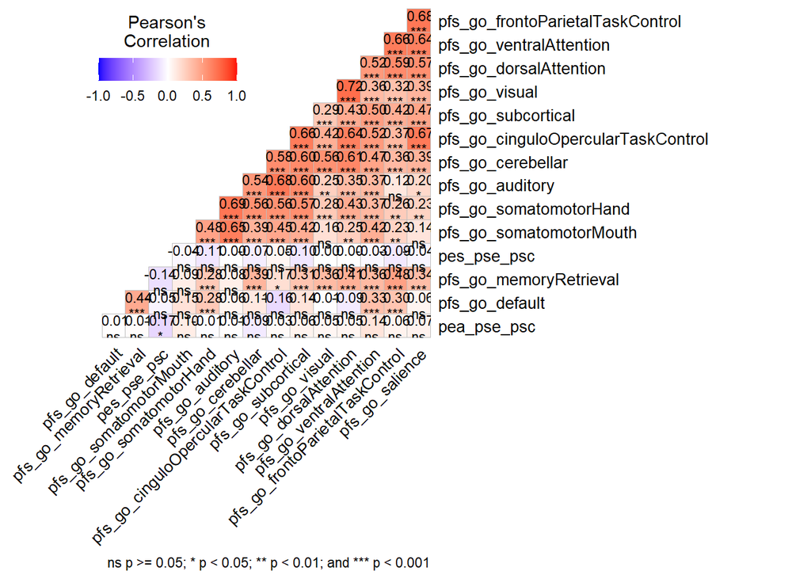

```r
plot(pe_pfsgo_corr, col.low = "blue", col.mid = "white", col.high ="red", order = "original")
```

```r
# Supplementary analyses: partial PES-fsgo correlations controlling for StopAcc
# Correlation between pes_pse_psc and networks controlling for StopAcc
vars <- c("pes_pse_psc", "pea_pse_psc", 'fsgo_somatomotorHand', 'fsgo_somatomotorMouth', 'fsgo_cinguloOpercularTaskControl', 'fsgo_auditory', 'fsgo_default', 'fsgo_memoryRetrieval', 'fsgo_visual', 'fsgo_frontoParietalTaskControl', 'fsgo_salience', 'fsgo_subcortical', 'fsgo_ventralAttention', 'fsgo_dorsalAttention', 'fsgo_cerebellar')
results <- data.frame(variable = character(), estimate = numeric(), p.value = numeric(), stringsAsFactors = FALSE)
for (v in vars) {
  res <- pcor.test(df[[v]], df$pes_pse_psc, df[, c("StopAcc", "GoRT", "sex")])
  results <- rbind(results, data.frame(variable = v, estimate = res$estimate, p.value = res$p.value))}
print(results)
```

```
##                            variable     estimate    p.value
## 1                       pes_pse_psc -1.000000000 0.00000000
## 2                       pea_pse_psc -0.096350089 0.25572390
## 3              fsgo_somatomotorHand -0.091828958 0.27881192
## 4             fsgo_somatomotorMouth -0.041814432 0.62249706
## 5  fsgo_cinguloOpercularTaskControl -0.085937961 0.31094126
## 6                     fsgo_auditory -0.116241678 0.16985663
## 7                      fsgo_default  0.002634036 0.97527028
## 8              fsgo_memoryRetrieval -0.034495557 0.68467888
## 9                       fsgo_visual -0.096577815 0.25459681
## 10   fsgo_frontoParietalTaskControl -0.101674761 0.23026150
## 11                    fsgo_salience -0.149908241 0.07602075
## 12                 fsgo_subcortical -0.140345532 0.09693412
## 13            fsgo_ventralAttention  0.091919227 0.27833764
## 14             fsgo_dorsalAttention -0.083906325 0.32256085
## 15                  fsgo_cerebellar -0.120295338 0.15535225
```

```r
pcor.test(df$pes_pse_psc, df$fsgo_subcortical, df[, c("StopAcc", "GoRT", "sex")])
```

```
##     estimate    p.value statistic   n gp  Method
## 1 -0.1403455 0.09693412  -1.67119 144  3 pearson
```

## Remove outliers and standardize data

```r
# Exclude individuals with AUDIT_T0 >= 8
# df <- df %>%
#   filter(AUDIT_T0 < 8)
dfUnscaled <- df # Save the unscaled data for later descriptive statistics

# List of variables to scale
variables_to_scale <- c("CTQ_TotalCorrected", "AdChild", "SUPPS_Impulsive", "BIS_Impulsive", "CDRISC_Resilience", "stateAnxiety",   "traitAnxiety", "BDI_depression", "GoAcc", "GoRT", "StopAcc", "SSD", "SSRT", "pea_pse_psc", "pes_pse_psc",

"rIFG_ss_go", "lIFG_ss_go", "rInsula_ss_go", "lInsula_ss_go", "biIFGInsula_ss_go",  "rSFG_ssrt", "lSFG_ssrt", "biIFGSFGInsula_ssrt", "lMidOrbG_socialMis", "lSMedG_socialMis", "lMidFGIFG_socialMis", "lMidFG_socialMis", "ave_socialMis",

"net_7_1", "net_7_2", "net_7_3", "net_7_4", "net_7_5", "net_7_6", "net_7_7", "net_17_1", "net_17_2", "net_17_3", "net_17_4", "net_17_5", "net_17_6", "net_17_7", "net_17_8", "net_17_9", "net_17_10", "net_17_11", "net_17_12", "net_17_13", "net_17_14", "net_17_15", "net_17_16", "net_17_17",

"ss_somatomotorHand", "ss_somatomotorMouth", "ss_cinguloOpercularTaskControl", "ss_auditory", "ss_default", "ss_memoryRetrieval", "ss_visual", "ss_frontoParietalTaskControl", "ss_salience", "ss_subcortical", "ss_ventralAttention", "ss_dorsalAttention", "ss_cerebellar",

"fs_somatomotorHand", "fs_somatomotorMouth", "fs_cinguloOpercularTaskControl", "fs_auditory", "fs_default", "fs_memoryRetrieval", "fs_visual", "fs_frontoParietalTaskControl", "fs_salience", "fs_subcortical", "fs_ventralAttention", "fs_dorsalAttention", "fs_cerebellar",

"ssgo_somatomotorHand", "ssgo_somatomotorMouth", "ssgo_cinguloOpercularTaskControl", "ssgo_auditory", "ssgo_default", "ssgo_memoryRetrieval", "ssgo_visual", "ssgo_frontoParietalTaskControl", "ssgo_salience", "ssgo_subcortical", "ssgo_ventralAttention", "ssgo_dorsalAttention", "ssgo_cerebellar",

"fsgo_somatomotorHand", "fsgo_somatomotorMouth", "fsgo_cinguloOpercularTaskControl", "fsgo_auditory", "fsgo_default", "fsgo_memoryRetrieval", "fsgo_visual", "fsgo_frontoParietalTaskControl", "fsgo_salience", "fsgo_subcortical", "fsgo_ventralAttention", "fsgo_dorsalAttention", "fsgo_cerebellar",

"ssfs_somatomotorHand", "ssfs_somatomotorMouth", "ssfs_cinguloOpercularTaskControl", "ssfs_auditory", "ssfs_default", "ssfs_memoryRetrieval", "ssfs_visual", "ssfs_frontoParietalTaskControl", "ssfs_salience", "ssfs_subcortical", "ssfs_ventralAttention", "ssfs_dorsalAttention", "ssfs_cerebellar",

"fsss_somatomotorHand", "fsss_somatomotorMouth", "fsss_cinguloOpercularTaskControl", "fsss_auditory", "fsss_default", "fsss_memoryRetrieval", "fsss_visual", "fsss_frontoParietalTaskControl", "fsss_salience", "fsss_subcortical", "fsss_ventralAttention", "fsss_dorsalAttention", "fsss_cerebellar")

df <- df %>%
  mutate_at(vars(all_of(variables_to_scale)), scale)

# Detect multivariate outliers. First we create a numeric matrix of the variables of interest.
numeric_data <- df[, c("AUDIT_T0", 'SocialMis_T0', "AdChild",  "sex", "SSRT", "StopAcc", "pes_pse_psc", "ssgo_auditory", "ssgo_default", "ssgo_memoryRetrieval", "ssgo_visual", "fsgo_salience", "fsgo_subcortical")]

# Calculate Mahalanobis distance
mahalanobis_dist <- mahalanobis(numeric_data, colMeans(numeric_data, na.rm = TRUE), cov(numeric_data, use = "pairwise.complete.obs"))

# Calculate the threshold using chi-square distribution (p = .05)
df_chi <- ncol(numeric_data)  # DF = number of variables
threshold <- qchisq(p = 0.95, df = df_chi)
outliers <- mahalanobis_dist > threshold
dfclean <- df[!outliers, ]
dfUnscaled <- dfUnscaled[!outliers, ]

# Print summary
cat("Number of outliers detected:", sum(outliers), "\n")
```

```
## Number of outliers detected: 11
```

```r
cat("Number of observations retained:", nrow(dfclean), "\n")
```

```
## Number of observations retained: 133
```

```r
cat("Percentage of data removed:", round(sum(outliers)/length(outliers) * 100, 2), "%\n")
```

```
## Percentage of data removed: 7.64 %
```

```r
print(df$mriID[outliers])
```

```
##  [1] "LIA002" "LIA020" "LIA043" "LIA045" "LIA053" "LIA068" "LIA084" "LIA086" "LIA100" "LIA103" "LIA119"
```

## Examine post-error performance after removing outliers, and examine if stop accuracy differs from 50%

```r
# Descriptive statistics
# pgc: post-go correct; pse: post-stop error; psc: post-stop correct; pea: post-error accuracy; pes: post-error slowing
vars <- c("pgc_trials", "pse_trials", "psc_trials", "post_stop_cor_acc", "post_stop_err_acc", "pea_pse_psc", "post_stop_cor_rt", "post_stop_err_rt", "pes_pse_psc")
for (v in vars) {
  cat("\nDescriptive stats after removing outliers for", v, ":\n")
  x <- dfUnscaled[[v]]
  cat(sprintf("Mean = %.3f, SD = %.3f, range: %.3f - %.3f (n = %d)\n",
            mean(x, na.rm = TRUE), sd(x, na.rm = TRUE), min(x, na.rm = TRUE), max(x, na.rm = TRUE), sum(!is.na(x))))}
```

```
##
## Descriptive stats after removing outliers for pgc_trials :
## Mean = 119.316, SD = 5.178, range: 79.000 - 122.000 (n = 133)
##
## Descriptive stats after removing outliers for pse_trials :
## Mean = 26.383, SD = 2.776, range: 14.000 - 33.000 (n = 133)
##
## Descriptive stats after removing outliers for psc_trials :
## Mean = 17.617, SD = 2.776, range: 11.000 - 30.000 (n = 133)
##
## Descriptive stats after removing outliers for post_stop_cor_acc :
## Mean = 98.151, SD = 5.077, range: 63.889 - 100.000 (n = 133)
##
## Descriptive stats after removing outliers for post_stop_err_acc :
## Mean = 97.873, SD = 4.036, range: 75.000 - 100.000 (n = 133)
##
## Descriptive stats after removing outliers for pea_pse_psc :
## Mean = -0.437, SD = 3.589, range: -8.333 - 11.111 (n = 133)
##
## Descriptive stats after removing outliers for post_stop_cor_rt :
## Mean = 696.993, SD = 153.972, range: 398.231 - 1162.216 (n = 133)
##
## Descriptive stats after removing outliers for post_stop_err_rt :
## Mean = 734.821, SD = 170.996, range: 408.078 - 1203.242 (n = 133)
##
## Descriptive stats after removing outliers for pes_pse_psc :
## Mean = 37.776, SD = 66.063, range: -129.258 - 187.478 (n = 133)
```

```r
# Paired t-test with effect size and 95%CI
paired_ttest <- function(x, y, xname, yname) {
  res <- t.test(x, y, paired = TRUE)
  d <- cohen.d(x, y, paired = TRUE, na.rm = TRUE)
  cat("\nPaired t-test:", xname, "vs.", yname, "\n")
  cat(sprintf("t = %.3f (p = %.3f, Cohen's d = %.3f, 95%% CI = %.3f to %.3f)\n",
            res$statistic, res$p.value, d$estimate, res$conf.int[1], res$conf.int[2]))}

# Run paired t-tests using dfUnscaled
paired_ttest(dfUnscaled$post_stop_err_acc, dfUnscaled$post_go_cor_acc, "post_stop_err_acc", "post_go_cor_acc")
```

```
##
## Paired t-test: post_stop_err_acc vs. post_go_cor_acc
## t = -1.136 (p = 0.258, Cohen's d = -0.093, 95% CI = -0.919 to 0.248)
```

```r
paired_ttest(dfUnscaled$post_stop_err_acc, dfUnscaled$post_stop_cor_acc, "post_stop_err_acc", "post_stop_cor_acc")
```

```
##
## Paired t-test: post_stop_err_acc vs. post_stop_cor_acc
## t = -0.705 (p = 0.482, Cohen's d = -0.060, 95% CI = -1.060 to 0.503)
```

```r
paired_ttest(dfUnscaled$post_stop_err_rt, dfUnscaled$post_go_cor_rt, "post_stop_err_rt", "post_go_cor_rt")
```

```
##
## Paired t-test: post_stop_err_rt vs. post_go_cor_rt
## t = -4.413 (p = 0.000, Cohen's d = -0.125, 95% CI = -32.600 to -12.420)
```

```r
paired_ttest(dfUnscaled$post_stop_err_rt, dfUnscaled$post_stop_cor_rt, "post_stop_err_rt", "post_stop_cor_rt")
```

```
##
## Paired t-test: post_stop_err_rt vs. post_stop_cor_rt
## t = 6.751 (p = 0.000, Cohen's d = 0.225, 95% CI = 26.744 to 48.912)
```

```r
# normality
print(shapiro_res <- tryCatch(shapiro.test(dfUnscaled$StopAcc), error = function(e) e))
```

```
##
##  Shapiro-Wilk normality test
##
## data:  dfUnscaled$StopAcc
## W = 0.85327, p-value = 3.621e-10
```

```r
# one-sample t-test vs 50 with 95% CI
t_res <- t.test(dfUnscaled$StopAcc, mu = 50, alternative = "two.sided", conf.level = 0.95)
print(t_res)
```

```
##
##  One Sample t-test
##
## data:  dfUnscaled$StopAcc
## t = -21.912, df = 132, p-value < 2.2e-16
## alternative hypothesis: true mean is not equal to 50
## 95 percent confidence interval:
##  38.85974 40.70456
## sample estimates:
## mean of x
##  39.78215
```

```r
cat("95% CI for mean:", round(t_res$conf.int[1],2), "-", round(t_res$conf.int[2],2), "\n\n")
```

```
## 95% CI for mean: 38.86 - 40.7
```

```r
cat("Cohen's d (one-sample) =", round(d <- (mean(df$StopAcc) - 50) / sd(df$StopAcc), 3), "\n")
```

```
## Cohen's d (one-sample) = -50
```

```r
print(summary(dfUnscaled$StopAcc))
```

```
##    Min. 1st Qu.  Median    Mean 3rd Qu.    Max.
##   32.05   36.00   38.57   39.78   41.24   67.95
```

### Distribution of PES and PEA after removing outliers

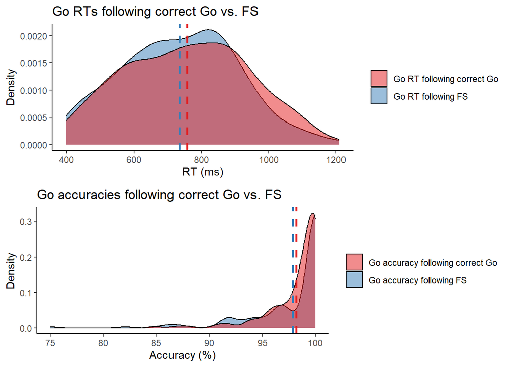

```r
mean_err_rt <- mean(dfUnscaled$post_stop_err_rt, na.rm = TRUE)
mean_go_cor_rt <- mean(dfUnscaled$post_go_cor_rt, na.rm = TRUE)
mean_stop_cor_rt <- mean(dfUnscaled$post_stop_cor_rt, na.rm = TRUE)
mean_err_acc <- mean(dfUnscaled$post_stop_err_acc, na.rm = TRUE)
mean_go_cor_acc <- mean(dfUnscaled$post_go_cor_acc, na.rm = TRUE)
mean_stop_cor_acc <- mean(dfUnscaled$post_stop_cor_acc, na.rm = TRUE)

# Post-stop-error vs post-go-correct RTs
p1 <- ggplot(dfUnscaled, aes(x = post_stop_err_rt)) +
  geom_density(aes(fill = "post_stop_err_rt"), alpha = 0.5) +
  geom_density(aes(x = post_go_cor_rt, fill = "post_go_cor_rt"), alpha = 0.5) +
  geom_vline(xintercept = mean_err_rt, color = "#377eb8", linetype = "dashed", linewidth = 1) +
  geom_vline(xintercept = mean_go_cor_rt, color = "#e41a1c", linetype = "dashed", linewidth = 1) +
  labs(title = "Go RTs following correct Go vs. FS", x = "RT (ms)", y = "Density", fill = "Variable") +
  scale_fill_manual(name = NULL, values = c("post_stop_err_rt" = "#377eb8", "post_go_cor_rt" = "#e41a1c"),
                    labels = c("post_stop_err_rt" = "Go RT following FS", "post_go_cor_rt" = "Go RT following correct Go")) +
  theme_classic()

# Post-stop-error vs post-stop-correct RTs
p2 <- ggplot(dfUnscaled, aes(x = post_stop_err_rt)) +
  geom_density(aes(fill = "post_stop_err_rt"), alpha = 0.5) +
  geom_density(aes(x = post_stop_cor_rt, fill = "post_stop_cor_rt"), alpha = 0.5) +
  geom_vline(xintercept = mean_err_rt, color = "#377eb8", linetype = "dashed", linewidth = 1) +
  geom_vline(xintercept = mean_stop_cor_rt, color = "#e41a1c", linetype = "dashed", linewidth = 1) +
  labs(title = "Go RTs following SS vs. FS", x = "RT (ms)", y = "Density", fill = "Variable") +
  scale_fill_manual(name = NULL, values = c("post_stop_err_rt" = "#377eb8", "post_stop_cor_rt" = "#e41a1c"),
                    labels = c("post_stop_err_rt" = "Go RT following FS", "post_stop_cor_rt" = "Go RT following SS")) +
  theme_classic()

# Post-stop-error vs post-go-correct Accuracies
p3 <- ggplot(dfUnscaled, aes(x = post_stop_err_acc)) +
  geom_density(aes(fill = "post_stop_err_acc"), alpha = 0.5) +
  geom_density(aes(x = post_go_cor_acc, fill = "post_go_cor_acc"), alpha = 0.5) +
  geom_vline(xintercept = mean_err_acc, color = "#377eb8", linetype = "dashed", linewidth = 1) +
  geom_vline(xintercept = mean_go_cor_acc, color = "#e41a1c", linetype = "dashed", linewidth = 1) +
  labs(title = "Go accuracies following correct Go vs. FS", x = "Accuracy (%)", y = "Density", fill = "Variable") +
  scale_fill_manual(name = NULL, values = c("post_stop_err_acc" = "#377eb8", "post_go_cor_acc" = "#e41a1c"),
                    labels = c("post_stop_err_acc" = "Go accuracy following FS", "post_go_cor_acc" = "Go accuracy following correct Go")) +
  theme_classic()

# Post-stop-error vs post-stop-correct Accuracies
p4 <- ggplot(dfUnscaled, aes(x = post_stop_err_acc)) +
  geom_density(aes(fill = "post_stop_err_acc"), alpha = 0.5) +
  geom_density(aes(x = post_stop_cor_acc, fill = "post_stop_cor_acc"), alpha = 0.5) +
  geom_vline(xintercept = mean_err_acc, color = "#377eb8", linetype = "dashed", linewidth = 1) +
  geom_vline(xintercept = mean_stop_cor_acc, color = "#e41a1c", linetype = "dashed", linewidth = 1) +
  labs(title = "Go accuracies following SS vs. FS", x = "Accuracy (%)", y = "Density", fill = "Variable") +
  scale_fill_manual(name = NULL, values = c("post_stop_err_acc" = "#377eb8", "post_stop_cor_acc" = "#e41a1c"),
                    labels = c("post_stop_err_acc" = "Go accuracy following FS", "post_stop_cor_acc" = "Go accuracy following SS")) +
  theme_classic()

# Based on the t-tests and distribution plots, we can see significant post-error speeding (i.e., negative PES) when comparing post-stop-error RT to post-go-correct RT, and significant post-error-slowing (i.e., positive PES) when comparing post-stop-error RT to post-stop correct RT.
ggarrange(p1, p3, ncol = 1, nrow = 2, common.legend = FALSE, legend = "right")
```

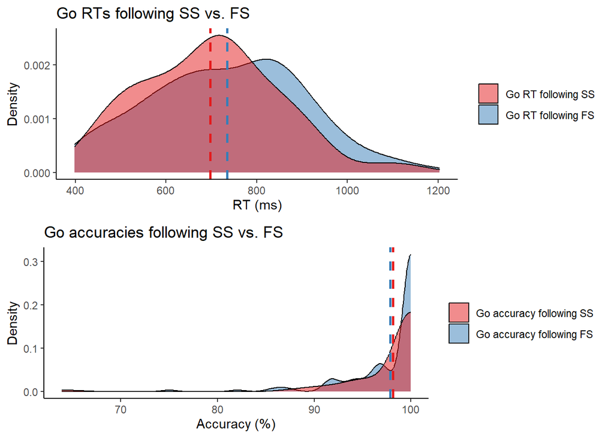

```r
ggarrange(p2, p4, ncol = 1, nrow = 2, common.legend = FALSE, legend = "right")
```

```r
tiff('Post_stop_err_post_go_cor_distribution_wo.outlier.tiff', width = 2000, height = 2000, res = 300)
ggarrange(p1, p3, ncol = 1, nrow = 2, common.legend = FALSE, legend = "right")
dev.off()
```

```r
tiff('Post_stop_err_post_stop_cor_distribution_wo.outlier.tiff', width = 2000, height = 2000, res = 300)
ggarrange(p2, p4, ncol = 1, nrow = 2, common.legend = FALSE, legend = "right")
dev.off()
```

# Sample characteristics w/o outliers

```r
# Display counts and proportions for categorical variables
cat_vars <- c("sex", "race", "ethnicity")

for (var in cat_vars) {
  cat("\nDescriptive statistics for", var, ":\n")
  print(table(dfclean[[var]], useNA = "ifany"))
  print(prop.table(table(dfclean[[var]], useNA = "ifany")))}
```

```
##
## Descriptive statistics for sex :
##
##  0  1
## 86 47
##
##         0         1
## 0.6466165 0.3533835
##
## Descriptive statistics for race :
##
## American Indian or Alaska Native                            Asian        Black or African American               More than One Race                            White                             <NA>
##                                1                               34                               11                               12                               74                                1
##
## American Indian or Alaska Native                            Asian        Black or African American               More than One Race                            White                             <NA>
##                      0.007518797                      0.255639098                      0.082706767                      0.090225564                      0.556390977                      0.007518797
##
## Descriptive statistics for ethnicity :
##
##     Hispanic or Latino Not Hispanic or Latino
##                     17                    116
##
##     Hispanic or Latino Not Hispanic or Latino
##              0.1278195              0.8721805
```

```r
# Count n in each wave
n_T0 <- sum(!is.na(dfclean$AUDIT_T0) & !is.na(dfclean$SocialMis_T0))
n_T1 <- sum(!is.na(dfclean$AUDIT_T1) & !is.na(dfclean$SocialMis_T1))
n_T2 <- sum(!is.na(dfclean$AUDIT_T2) & !is.na(dfclean$SocialMis_T2))
n_T3 <- sum(!is.na(dfclean$AUDIT_T3) & !is.na(dfclean$SocialMis_T3))

cat("T0:", n_T0, "\nT1:", n_T1, "\nT2:", n_T2, "\nT3:", n_T3, "\n")
```

```
## T0: 133
## T1: 101
## T2: 71
## T3: 64
```

```r
# Count by sex for each wave
count_by_sex <- function(audit, socialmis, sex) {
  table(
    sex = dfclean[[sex]][!is.na(dfclean[[audit]]) & !is.na(dfclean[[socialmis]])],
    useNA = "ifany")}

cat("T0:\n"); print(count_by_sex("AUDIT_T0", "SocialMis_T0", "sex"))
```

```
## T0:
```

```
## sex
##  0  1
## 86 47
```

```r
cat("T1:\n"); print(count_by_sex("AUDIT_T1", "SocialMis_T1", "sex"))
```

```
## T1:
```

```
## sex
##  0  1
## 68 33
```

```r
cat("T2:\n"); print(count_by_sex("AUDIT_T2", "SocialMis_T2", "sex"))
```

```
## T2:
```

```
## sex
##  0  1
## 52 19
```

```r
cat("T3:\n"); print(count_by_sex("AUDIT_T3", "SocialMis_T3", "sex"))
```

```
## T3:
```

```
## sex
##  0  1
## 46 18
```

## Descriptive statistics for questionnaire and behavioral data w/o outliers

```r
vars <- c("AUDIT_T0", "AUDIT_T1", "AUDIT_T2", "AUDIT_T3", "SocialMis_T0", "SocialMis_T1", "SocialMis_T2", "SocialMis_T3", "AdChild", "GoAcc", "GoRT", "StopAcc", "SSD", "SSRT", "pea_pse_psc", "pes_pse_psc")
desc <- map_dfr(vars, ~{
  x <- dfUnscaled[[.x]]
  mean_x <- mean(x, na.rm = TRUE)
  sd_x   <- sd(x, na.rm = TRUE)
  n_x    <- sum(!is.na(x))
  tibble(Variable = .x, Mean = mean_x, SD = sd_x, N = n_x,
         Summary = sprintf("%.2f (%.2f), %d", mean_x, sd_x, n_x))})
knitr::kable(desc %>% select(Variable, Summary), format = "html", caption = "Descriptive statistics") %>%
  kableExtra::kable_styling(full_width = FALSE, bootstrap_options = c("striped", "hover", "condensed"))
```

Descriptive statistics

| Variable | Summary |
| --- | --- |
| AUDIT_T0 | 2.29 (2.59), 133 |
| AUDIT_T1 | 3.23 (3.56), 105 |
| AUDIT_T2 | 3.79 (3.35), 77 |
| AUDIT_T3 | 3.82 (3.08), 72 |
| SocialMis_T0 | 10.09 (3.15), 133 |
| SocialMis_T1 | 9.47 (3.42), 101 |
| SocialMis_T2 | 9.15 (3.41), 71 |
| SocialMis_T3 | 8.47 (2.81), 64 |
| AdChild | 1.43 (1.65), 133 |
| GoAcc | 97.91 (4.02), 133 |
| GoRT | 733.27 (167.15), 133 |
| StopAcc | 39.78 (5.38), 133 |
| SSD | 524.81 (181.94), 133 |
| SSRT | 251.20 (47.29), 133 |
| pea_pse_psc | -0.44 (3.59), 133 |
| pes_pse_psc | 37.78 (66.06), 133 |

```r
# Shapiro-Wilk normality test
shapiro.test(dfUnscaled$StopAcc[!is.na(dfUnscaled$StopAcc)])
```

```
##
##  Shapiro-Wilk normality test
##
## data:  dfUnscaled$StopAcc[!is.na(dfUnscaled$StopAcc)]
## W = 0.85327, p-value = 3.621e-10
```

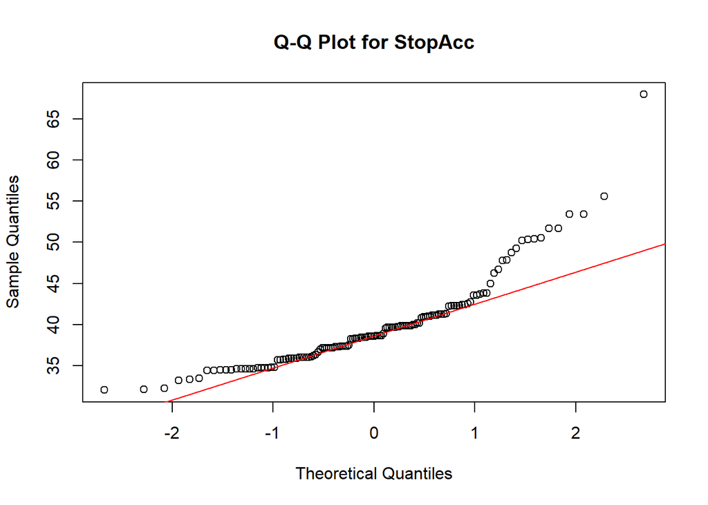

```r
# Q-Q plot
qqnorm(dfUnscaled$StopAcc, main = "Q-Q Plot for StopAcc")
qqline(dfUnscaled$StopAcc, col = "red")
```

```r
stopacc_range <- range(dfUnscaled$StopAcc, na.rm = TRUE)
print(stopacc_range)
```

```
## [1] 32.05128 67.94872
```

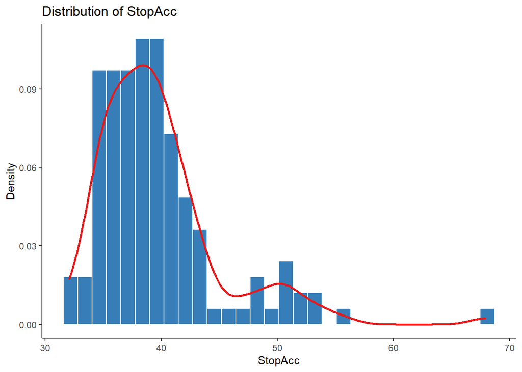

```r
library(ggplot2)
ggplot(dfUnscaled, aes(x = StopAcc)) +
  geom_histogram(aes(y = ..density..), bins = 30, fill = "#377eb8", color = "white", na.rm = TRUE) +
  geom_density(color = "#e41a1c", linewidth = 1, na.rm = TRUE) +
  labs(title = "Distribution of StopAcc", x = "StopAcc", y = "Density") +
  theme_classic()
```

## Correlations between questionnaire and behavioral data w/o outliers

```r
corr_df <- dfUnscaled[,names(dfUnscaled) %in% c('AUDIT_T0', 'SocialMis_T0', 'AdChild', "SUPPS_Impulsive", "BIS_Impulsive", "CDRISC_Resilience", "stateAnxiety", "traitAnxiety", "BDI_depression", "GoAcc", "GoRT", "StopAcc", "SSRT", "pea_pse_psc", "pes_pse_psc")]

corr <- cor(corr_df, use = "pairwise.complete.obs")
rTest <- cor.mtest(corr_df, conf.level = 0.95)
tiff('questionnaire-behavior corr.tiff', width = 2000, height = 2000, res = 300)
corrplot(corr, p.mat = rTest$p, method = 'color', diag = FALSE, type = 'upper', order = 'original',
         sig.level = c(0.001, 0.01, 0.05), pch.cex = 0.9, insig = 'label_sig', pch.col = 'grey20', col = colorRampPalette(c("blue", "white", "red"))(10))
dev.off()
```

```r
correltable(data = corr_df)
```

```
## $table
##                   GoAcc GoRT   StopAcc SSRT    pea_pse_psc pes_pse_psc AUDIT_T0 AdChild SocialMis_T0 SUPPS_Impulsive BIS_Impulsive CDRISC_Resilience stateAnxiety traitAnxiety BDI_depression
## GoAcc                   -.26** -.40*** -.39*** -.05        .26**       .15      .02     .09          .08             .13           -.02              .05          .04          .03
## GoRT                           .82***  -.14    -.11        .30***      .00      .09     .03          .03             .03           .00               .07          .13          .10
## StopAcc                                -.13    -.06        .09         -.05     .11     -.02         -.03            -.09          .05               .03          .08          .03
## SSRT                                           .04         -.27**      .06      -.12    .06          -.09            -.03          -.11              -.01         -.05         .02
## pea_pse_psc                                                -.21*       .10      .04     .05          .05             .02           .02               -.01         -.01         -.02
## pes_pse_psc                                                            .01      .13     .04          .06             .07           -.07              .20*         .17          .01
## AUDIT_T0                                                                        .16     .09          .14             .12           -.01              .02          .06          .14
## AdChild                                                                                 .31***       .02             .09           -.11              .30***       .33***       .24**
## SocialMis_T0                                                                                         -.08            .06           -.26**            .55***       .58***       .51***
## SUPPS_Impulsive                                                                                                      .62***        .00               -.07         -.04         -.03
## BIS_Impulsive                                                                                                                      -.11              .08          .07          .06
## CDRISC_Resilience                                                                                                                                    -.39***      -.48***      -.11
## stateAnxiety                                                                                                                                                      .79***       .44***
## traitAnxiety                                                                                                                                                                   .50***
## BDI_depression
##
## $caption
## [1] "Note. This table presents Pearson correlation coefficients with pairwise deletion. N=2 missing SUPPS_Impulsive. N=2 missing BIS_Impulsive.  * p<.05, ** p<.01, *** p<.001"
```

```r
# If desired, partial correlation can be calculated
# pcor.test(df$cinguloOpercularTaskControl, df$SSRT, df$sex) # correlation between x and y when controlling for sex
```

# Hypothesis Testing

In the initial model by nlme, which is not shown in this markdown, we included the covariates (i.e., sex and AdChild), predictors (i.e., SocialMis and inhibition-related variables) and the interaction between predictors in the formulas of intercept and slope. We also modeled random intercept and random slope as we believe that people with a higher starting AUDIT can have a less change in AUDIT slope. However, this approach can cause convergence issue in several models. Therefore, we decided to analyze two types of models using lmer: 1. a cross-sectional model using baseline data only: AUDIT_T0 ~ sex + AdChild + SocialMis + Inhibition + SocialMis*Inhibition, and 2. a trajectory model: AUDIT ~ sex + AdChild + SocialMis +Inhibition + SocialMis*Inhibition*Time.

There are 16 models being examined in total, each one has its own moderator: 1 with SSRT, 1 with SUPPS, 1 with BIS, and 13 with brain network activations.

## Cross-sectional model (i.e., with baseline data only)

```r
base.lme <- (lm(AUDIT_T0 ~ 1 + sex + AdChild + SocialMis_T0, data = dfclean, na.action = na.exclude))
summary(base.lme)
```

```
##
## Call:
## lm(formula = AUDIT_T0 ~ 1 + sex + AdChild + SocialMis_T0, data = dfclean,
##     na.action = na.exclude)
##
## Residuals:
##     Min      1Q  Median      3Q     Max
## -3.4268 -1.9789 -0.7026  1.2974  9.0453
##
## Coefficients:
##              Estimate Std. Error t value Pr(>|t|)
## (Intercept)   2.02199    0.80197   2.521   0.0129 *
## sex          -0.40225    0.48292  -0.833   0.4064
## AdChild       0.35282    0.26063   1.354   0.1782
## SocialMis_T0  0.04197    0.07491   0.560   0.5763
## ---
## Signif. codes:  0 '***' 0.001 '**' 0.01 '*' 0.05 '.' 0.1 ' ' 1
##
## Residual standard error: 2.576 on 129 degrees of freedom
## Multiple R-squared:  0.03339,    Adjusted R-squared:  0.01091
## F-statistic: 1.485 on 3 and 129 DF,  p-value: 0.2216
```

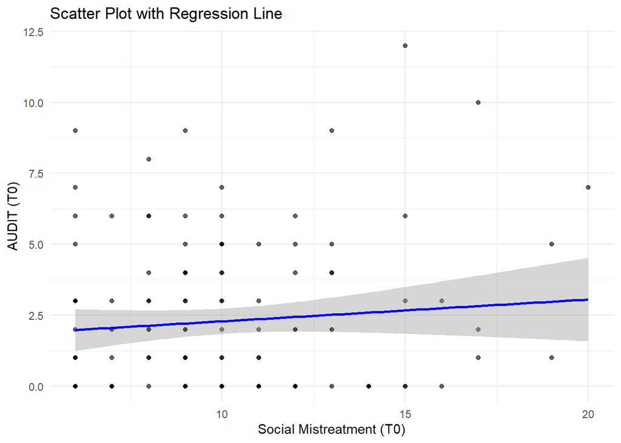

```r
ggplot(data = dfclean, aes(x = SocialMis_T0, y = AUDIT_T0)) +
  geom_point(alpha = 0.6) +  # Scatter points
  geom_smooth(method = "lm", formula = y ~ x, color = "blue") +  # Regression line
  labs(
    x = "Social Mistreatment (T0)",
    y = "AUDIT (T0)",
    title = "Scatter Plot with Regression Line"
  ) + theme_minimal()
```